# assignment Markdown

## Task 3 Write the code to analyse the factors that might influence the hospitalisation rate (ambulatory, emergency, inpatient, urgent care) for the COVID patient (confirmed or suspected) in the dataset.

### Any factors in the dataset, such as age, gender, zip code, marital status, race and county, can be considered. Pick 2 of the factors and explain if there is a trend that explains the variation.

```r
#Detect column names dynamically
id_col <- names(patient_data)[grepl("^Id$", names(patient_data), ignore.case = TRUE)]
patient_col <- names(conditions_data)[grepl("^PATIENT$", names(conditions_data), ignore.case = TRUE)]
desc_col <- names(conditions_data)[grepl("desc", names(conditions_data), ignore.case = TRUE)]

# Identify COVID or suspected COVID patients
covid_patients <- conditions_data |>
  filter(grepl("COVID|SARS|coronavirus", .data[[desc_col]], ignore.case = TRUE)) |>
  distinct(.data[[patient_col]]) |>
  rename(PATIENT = all_of(patient_col))

# Join with encounters and patient demographics
covid_encounters <- encounters_data |>
  rename(PATIENT = all_of(patient_col)) |>
  semi_join(covid_patients, by = "PATIENT") |>
  left_join(patient_data |> rename(ID = all_of(id_col)), by = c("PATIENT" = "ID"))

# Calculate patient age
covid_encounters <- covid_encounters |>
  mutate(
    BIRTHDATE = as.Date(BIRTHDATE),
    age = as.numeric(floor((Sys.Date() - BIRTHDATE) / 365.25)),
    age_group = case_when(
      age <= 18 ~ "0-18",
      age <= 35 ~ "19-35",
      age <= 50 ~ "36-50",
      age > 50  ~ "51+",
      TRUE ~ NA_character_
    )
  )
```

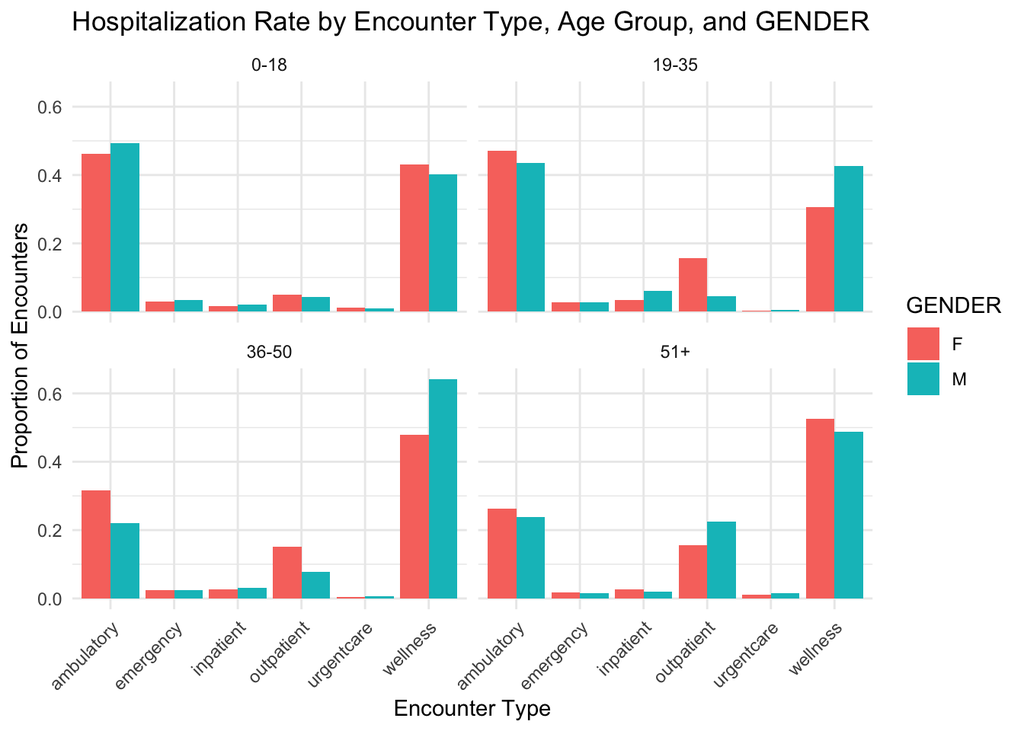

```r
#Summarize hospitalization rates by gender and age group
hospitalization_summary <- covid_encounters |>
  group_by(GENDER, age_group, ENCOUNTERCLASS) |>
  summarise(count = n(), .groups = "drop") |>
  group_by(GENDER, age_group) |>
  mutate(rate = count / sum(count)) |>
  ungroup()

# Visualize hospitalization patterns
ggplot(hospitalization_summary, aes(x = ENCOUNTERCLASS, y = rate, fill = GENDER)) +
  geom_col(position = "dodge") +
  facet_wrap(~ age_group) +
  labs(
    title = "Hospitalization Rate by Encounter Type, Age Group, and GENDER",
    x = "Encounter Type",
    y = "Proportion of Encounters"
  ) +
  theme_minimal() +
  theme(axis.text.x = element_text(angle = 45, hjust = 1))
```